This notebook illustrates amassing a medium-sized dataset (1 second of 32- or 64-bit float mono audio, essentially – a simple sine wave) using the `record_history` decorator, and then using the `stats.history_as_DataFrame` attribute to obtain that dataset as a Pandas DataFrame.

After that basic (and naive) example, we compare the performance of this approach to one that uses numpy's ability to vectorize the same computation, and conclude that *if you can vectorize, certainly you should do so*. (The example is naive precisely because no one would call the function `f` below in a `for` loop when it's possible to use `numpy` universal functions (*ufunc*s). When that alternative is unavailable, however, `record_history` can come in handy.)

# Using the `stats.history_as_DataFrame` attribute

```python
%matplotlib inline
import numpy as np
import pandas as pd
import matplotlib.pyplot as plt

from log_calls import record_history
```

```python
@record_history()
def f(freq, t):
    return np.sin(freq * 2 * np.pi * t)
```

```python
ran_t = np.arange(0.0, 1.0, 1/44100, dtype=np.float32)
ran_t
```

```
array([  0.00000000e+00,   2.26757365e-05,   4.53514731e-05, ...,
         9.99931931e-01,   9.99954641e-01,   9.99977291e-01], dtype=float32)
```

**Now, naively, call f 44,100 times in a `for` loop, and obtain its call history as a `Pandas` `DataFrame`:**

```python
#f.stats.clear_history()
for t in ran_t:
    f(17, t)
df = f.stats.history_as_DataFrame
```

**Examine and do stuff with it:**

```python
df.info()
```

```
<class 'pandas.core.frame.DataFrame'>
Int64Index: 44100 entries, 1 to 44100
Data columns (total 7 columns):
freq              44100 non-null int64
t                 44100 non-null float64
retval            44100 non-null float64
elapsed_secs      44100 non-null float64
timestamp         44100 non-null object
prefixed_fname    44100 non-null object
caller_chain      44100 non-null object
dtypes: float64(3), int64(1), object(3)
memory usage: 2.7 MB
```

```python
from IPython.display import display
display(df.head())
display(df.tail())
```

| call_num | freq | t | retval | elapsed_secs | timestamp | prefixed_fname | caller_chain |
| --- | --- | --- | --- | --- | --- | --- | --- |
| 1 | 17 | 0.000000 | 0.000000 | 0.000040 | 11/10/14 01:51:47.257050 | 'f' | ['<module>'] |
| 2 | 17 | 0.000023 | 0.002422 | 0.000016 | 11/10/14 01:51:47.257338 | 'f' | ['<module>'] |
| 3 | 17 | 0.000045 | 0.004844 | 0.000016 | 11/10/14 01:51:47.257570 | 'f' | ['<module>'] |
| 4 | 17 | 0.000068 | 0.007266 | 0.000016 | 11/10/14 01:51:47.257812 | 'f' | ['<module>'] |
| 5 | 17 | 0.000091 | 0.009688 | 0.000015 | 11/10/14 01:51:47.258043 | 'f' | ['<module>'] |

| call_num | freq | t | retval | elapsed_secs | timestamp | prefixed_fname | caller_chain |
| --- | --- | --- | --- | --- | --- | --- | --- |
| 44096 | 17 | 0.999887 | -0.012109 | 0.000014 | 11/10/14 01:51:57.920550 | 'f' | ['<module>'] |
| 44097 | 17 | 0.999909 | -0.009690 | 0.000014 | 11/10/14 01:51:57.920767 | 'f' | ['<module>'] |
| 44098 | 17 | 0.999932 | -0.007271 | 0.000014 | 11/10/14 01:51:57.920979 | 'f' | ['<module>'] |
| 44099 | 17 | 0.999955 | -0.004845 | 0.000014 | 11/10/14 01:51:57.921190 | 'f' | ['<module>'] |
| 44100 | 17 | 0.999977 | -0.002426 | 0.000013 | 11/10/14 01:51:57.921411 | 'f' | ['<module>'] |

```python
len(f.stats.history)
```

```
44100
```

```python
df[['t', 'retval']].head()
```

| call_num | t | retval |
| --- | --- | --- |
| 1 | 0.000000 | 0.000000 |
| 2 | 0.000023 | 0.002422 |
| 3 | 0.000045 | 0.004844 |
| 4 | 0.000068 | 0.007266 |
| 5 | 0.000091 | 0.009688 |

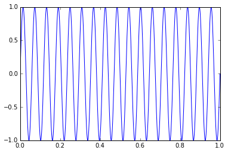

```python
plt.plot(df.t, df.retval);
```

# Comparing performance: `record_history` *vs* vectorization with numpy *ufunc*s

## (1) No decorator

### *With no decorator, it's ~2.8 orders of magnitude faster to use a function as a numpy ufunc than to call it in a for loop (looping through ran_t)*

```python
def g(freq, t):
    return np.sin(freq * 2 * np.pi * t)
```

#### Vectorized:

```python
nodeco_vectorized_secs = %timeit -o Hz_17 = g(17, ran_t)
nodeco_vectorized_secs.best
```

```
1000 loops, best of 3: 448 µs per loop
```

```
0.0004476831200008746
```

```python
Hz_17
```

```
array([ 0.        ,  0.00242209,  0.00484416, ..., -0.00727302,
       -0.00484692, -0.00242842], dtype=float32)
```

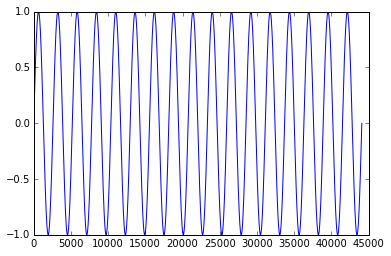

```python
plt.plot(Hz_17);
```

#### With a `for` loop:

```python
nodeco_loop_secs = %timeit -o for t in ran_t: g(7, t)
nodeco_loop_secs.best
```

```
1 loops, best of 3: 278 ms per loop
```

```
0.2777122740226332
```

```python
def comparison(slower, faster):
    'slower, faster: seconds'
    ratio = slower/faster
    order_of_magnitude = np.log10(ratio)
    return ratio, order_of_magnitude
```

```python
print("With record_history disabled:\n"
      "Vectorized approach is %d times (about %.1f orders of magnitude) faster"
      % comparison(slower=loop_secs.best, faster=vectorized_secs.best))
```

```
With record_history disabled:
Vectorized approach is 619 times (about 2.8 orders of magnitude) faster
```

**Now let's compare the performance of the `record_history`-decorated version (`f`) of the same function**

## (2) `record_history` disabled

### *With record_history disabled, it's ~3.6 orders of magnitude faster to use a function as a numpy ufunc than to call it in a for loop (looping through ran_t)*

```python
f.stats.clear_history()
f.record_history_settings.enabled = False
```

#### Vectorized:

```python
vectorized_secs_rh_disabled = %timeit -o Hz_17 = f(17, ran_t)
vectorized_secs_rh_disabled.best
```

```
1000 loops, best of 3: 489 µs per loop
```

```
0.0004893772610230371
```

#### With a `for` loop:

```python
loop_secs_rh_disabled = %timeit -o for t in ran_t: f(7, t)
loop_secs_rh_disabled.best
```

```
1 loops, best of 3: 1.98 s per loop
```

```
1.9756690169742797
```

```python
print("With record_history disabled:\n"
      "Vectorized approach is %d times (about %.1f orders of magnitude) faster"
      % comparison(slower=loop_secs_rh_disabled.best, faster=vectorized_secs_rh_disabled.best))
```

```
With record_history disabled:
Vectorized approach is 4037 times (about 3.6 orders of magnitude) faster
```

### Decorator overhead: about 7x slower (~0.9 orders of magnitude)

```python
print("Called in a for-loop, the no-decorator version is %d times (about %.1f orders of magnitude) faster"
      % comparison(slower=loop_secs_rh_disabled.best, faster=nodeco_loop_secs.best))
```

```
Called in a for-loop, the no-decorator version is 7 times (about 0.9 orders of magnitude) faster
```

## (3) `record_history` enabled

### *With record_history enabled, it's ~4.2 orders of magnitude faster to use a function as a numpy ufunc than to call it in a for loop (looping through ran_t)*

```python
f.record_history_settings.enabled = True
f.stats.clear_history()
```

#### Vectorized:

```python
vectorized_secs_rh_enabled = %timeit -o f.stats.clear_history(); Hz_17 = f(17, ran_t)
vectorized_secs_rh_enabled.best
```

```
1000 loops, best of 3: 705 µs per loop
```

```
0.0007048069210140966
```

```python
len(f.stats.history)
```

```
1
```

```python
def size_of_t_for_row(row):
    return f.stats.history[row].argvals[1].size

size_of_t_for_row(0)
```

```
44100
```

```python
f.stats.history[0].retval.size
```

```
44100
```

```python
f.stats.history
```

```
(CallRecord(call_num=1, argnames=['freq', 't'], argvals=(17, array([  0.00000000e+00,   2.26757365e-05,   4.53514731e-05, ...,
         9.99931931e-01,   9.99954641e-01,   9.99977291e-01], dtype=float32)), varargs=(), explicit_kwargs=OrderedDict(), defaulted_kwargs=OrderedDict(), implicit_kwargs={}, retval=array([ 0.        ,  0.00242209,  0.00484416, ..., -0.00727302,
       -0.00484692, -0.00242842], dtype=float32), elapsed_secs=0.00045490264892578125, timestamp='11/10/14 02:05:01.410089', prefixed_func_name='f', caller_chain=['inner']),)
```

```python
f.stats.clear_history()
```

#### With a `for` loop:

```python
loop_secs_rh_enabled = %timeit -o for t in ran_t: f(7, t); f.stats.clear_history()
loop_secs_rh_enabled.best
```

```
1 loops, best of 3: 10.6 s per loop
```

```
10.644794539985014
```

```python
print("With record_history enabled:\n"
      "Vectorized approach is %d times (about %.1f orders of magnitude) faster"
      % comparison(slower=loop_secs_rh_enabled.best, faster=vectorized_secs_rh_enabled.best))
```

```
With record_history enabled:
Vectorized approach is 15103 times (about 4.2 orders of magnitude) faster
```